# Programming with R Assignment #1

##### Section 3: (8 points) This problem requires finding the point of intersection of two functions. Using the function `y = cos(x/2) * sin(x/2)`, find where the curved line y = -(x/2)^3 intersects it within the range of values used in part (2) (i.e. 4001 equally-spaced values from -2 to 2). Plot both functions on the same display, and show the point of intersection. Present the coordinates of this point as text in the display.

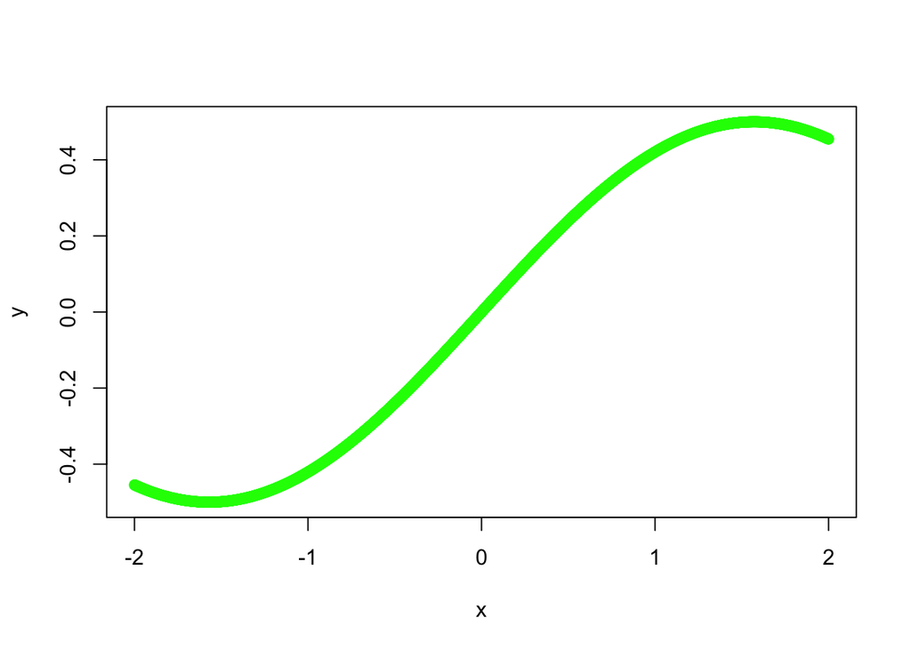

```r
function1<-function(x){
y<-cos(x/2)*sin(x/2)
return(y)
}
function2<-function(x){
y<--(x/2)**3
return(y)
}

x<-seq(-2,2,length.out = 4001)
y<-function1(x)
z<-function2(x)
plot(x,y,col="green")
```

```r
plot(x,z,col="blue")
f<-function(x) cos(x/2)*sin(x/2)+(x/2)**3
intrsect_x<-uniroot(f,c(-2,2))
intrsect_x
```

```
## $root
## [1] 0
##
## $f.root
## [1] 0
##
## $iter
## [1] 1
##
## $init.it
## [1] NA
##
## $estim.prec
## [1] 2
```

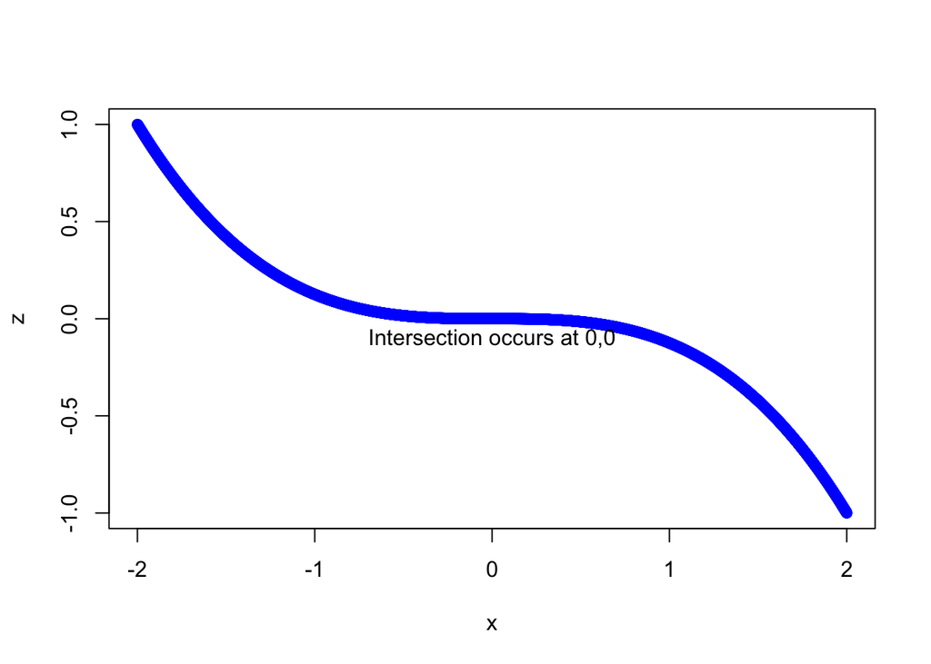

```r
text(0,-0.1,"Intersection occurs at 0,0")
```

##### Section 4: (12 points) Use the “trees” dataset for the following items. This dataset has three variables (Girth, Height, Volume) on 31 felled black cherry trees.

(4)(a) Use *data(trees)* to load the dataset. Check and output the structure with *str()*. Use *apply()* to return the median values for the three variables. Output these values. Using R and logicals, output the row number and the three measurements - Girth, Height and Volume - of any trees with Girth equal to median Girth. It is possible to accomplish this last request with one line of code.

```r
data(trees)
str(trees)
```

```
## 'data.frame':    31 obs. of  3 variables:
##  $ Girth : num  8.3 8.6 8.8 10.5 10.7 10.8 11 11 11.1 11.2 ...
##  $ Height: num  70 65 63 72 81 83 66 75 80 75 ...
##  $ Volume: num  10.3 10.3 10.2 16.4 18.8 19.7 15.6 18.2 22.6 19.9 ...
```

```r
trees
```

```
##    Girth Height Volume
## 1    8.3     70   10.3
## 2    8.6     65   10.3
## 3    8.8     63   10.2
## 4   10.5     72   16.4
## 5   10.7     81   18.8
## 6   10.8     83   19.7
## 7   11.0     66   15.6
## 8   11.0     75   18.2
## 9   11.1     80   22.6
## 10  11.2     75   19.9
## 11  11.3     79   24.2
## 12  11.4     76   21.0
## 13  11.4     76   21.4
## 14  11.7     69   21.3
```

[output cut: 17 more lines]

```r
apply(trees, 2, FUN = median) # median of Girth is 12.9
```

```
##  Girth Height Volume
##   12.9   76.0   24.2
```

```r
print(girth_median <- trees[trees$Girth == "12.9",]) #row 16 and 17
```

```
##    Girth Height Volume
## 16  12.9     74   22.2
## 17  12.9     85   33.8
```

(4)(b) Girth is defined as the diameter of a tree taken at 4 feet 6 inches from the ground. Convert each diameter to a radius, r. Calculate the cross-sectional area of each tree using pi times the squared radius. Present a stem-and-leaf plot of the radii, and a histogram of the radii in color. Plot Area (y-axis) versus Radius (x-axis) in color showing the individual data points. Label appropriately.

```r
trees$radius <- (trees$Girth/2)
radius <- trees$radius #add radius as column

func_a<-function(x){
a<-(pi*(x^2))
return(a)
}

x <-radius
a<-func_a(x)
a
```

```
##  [1]  54.10608  58.08805  60.82123  86.59015  89.92024  91.60884  95.03318
##  [8]  95.03318  96.76891  98.52035 100.28749 102.07035 102.07035 107.51315
## [15] 113.09734 130.69811 130.69811 138.92908 147.41138 149.57123 153.93804
## [22] 158.36769 165.12996 201.06193 208.67244 235.06182 240.52819 251.64943
## [29] 254.46900 254.46900 333.29156
```

```r
stem(radius)
```

```
##
##   The decimal point is at the |
##
##    4 | 234
##    5 | 34455667779
##    6 | 055799
##    7 | 013
##    8 | 0278
##    9 | 000
##   10 | 3
```

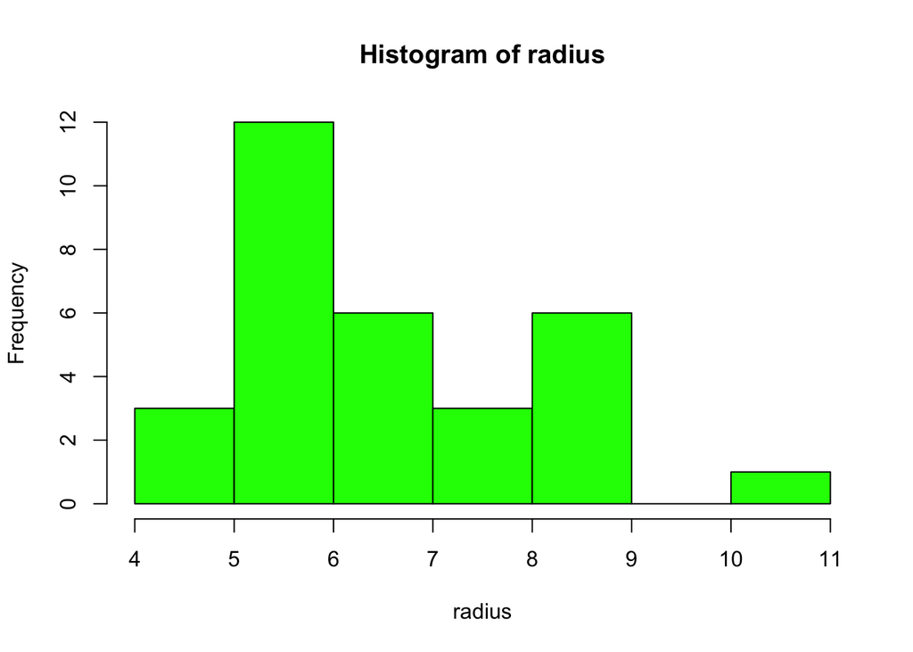

```r
hist(radius,col="green")
```

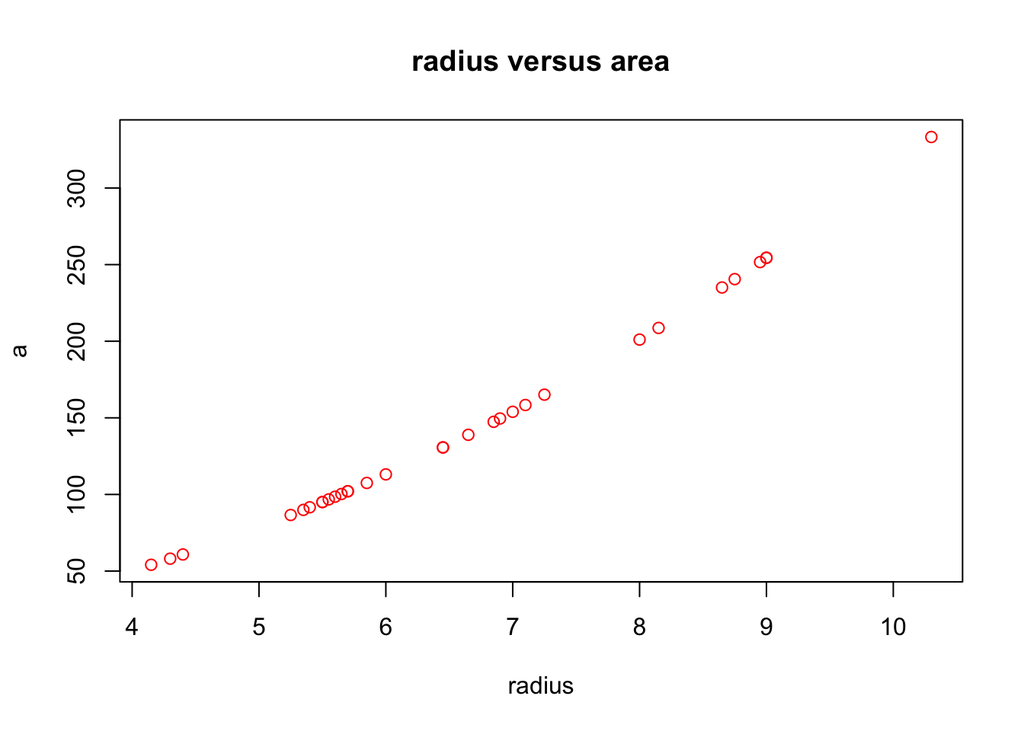

```r
plot(radius,a,main="radius versus area",col="red")
```

(4)(c) Present a horizontal, notched, colored boxplot of the areas calculated in (b). Title and label the axis.

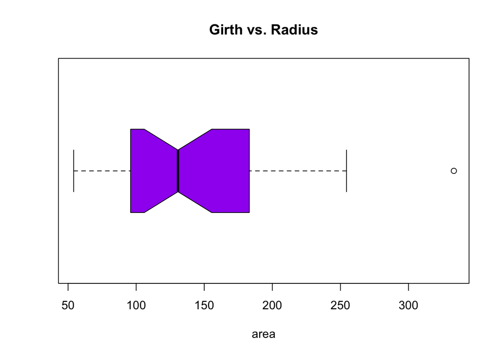

```r
boxplot(a,main="Girth vs. Radius", horizontal=TRUE, notch=TRUE,col="purple",xlab="area")
```

(4)(d) Demonstrate that the outlier revealed in the boxplot of Volume is not an extreme outlier. It is possible to do this with one line of code using *boxplot.stats()* or via ‘manual’ calculation and logicals. Identify the tree with the largest Volume and output on one line its row number and three measurements.

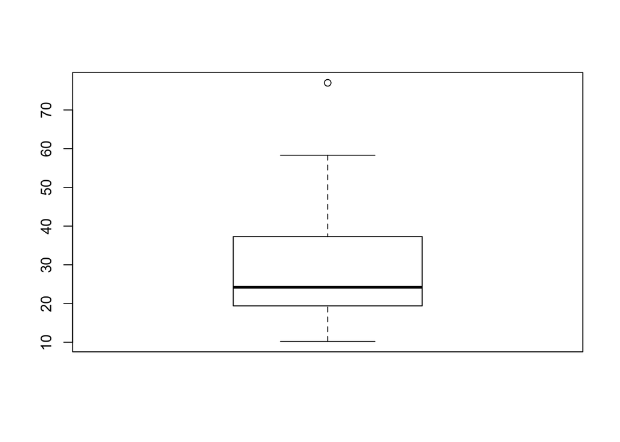

```r
boxplot(trees$Volume)
```

```r
trees_vol <-trees$Volume
boxplot.stats(trees_vol)
```

```
## $stats
## [1] 10.2 19.4 24.2 37.3 58.3
##
## $n
## [1] 31
##
## $conf
## [1] 19.1204 29.2796
##
## $out
## [1] 77
```

```r
colnames(trees)
```

```
## [1] "Girth"  "Height" "Volume" "radius"
```

```r
which.max(trees$Volume) #row 31
```

```
## [1] 31
```

```r
trees$rownumber <- seq.int(nrow(trees))
trees[31,]
```

```
##    Girth Height Volume radius rownumber
## 31  20.6     87     77   10.3        31
```

##### Section 5: (12 points) The exponential distribution is an example of a right-skewed distribution with outliers. This problem involves comparing it with a normal distribution which typically has very few outliers.

5(a) Use *set.seed(124)* and *rexp()* with n = 100, rate = 5.5 to generate a random sample designated as y. Generate a second random sample designated as x with *set.seed(127)* and *rnorm()* using n = 100, mean = 0 and sd = 0.15.

Generate a new object using *cbind(x, y)*. Do not output this object; instead, assign it to a new name. Pass this object to *apply()* and compute the inter-quartile range (IQR) for each column: x and y. Use the function *IQR()* for this purpose. Round the results to four decimal places and present (this exercise shows the similarity of the IQR values.).

For information about *rexp()*, use *help(rexp)* or *?rexp()*. **Do not output x or y.**

```r
set.seed(124)
y<-rexp(n=100,rate=5.5)
y
```

[output not shown]

```r
set.seed(127)
x<-rnorm(n=100,mean=0,sd=0.15)
x
```

[output not shown]

```r
data1 <- cbind(x,y)
inter_quartile <- apply(data1,2,IQR)
round(inter_quartile, digits = 4)
```

```
##      x      y
## 0.2041 0.2164
```

(5)(b) This item will illustrate the difference between a right-skewed distribution and a symmetric one. For base R plots, use *par(mfrow = c(2, 2))* to generate a display with four diagrams; *grid.arrange()* for ggplots. On the first row, for the normal results, present a histogram and a horizontal boxplot for x in color. For the exponential results, present a histogram and a horizontal boxplot for y in color.

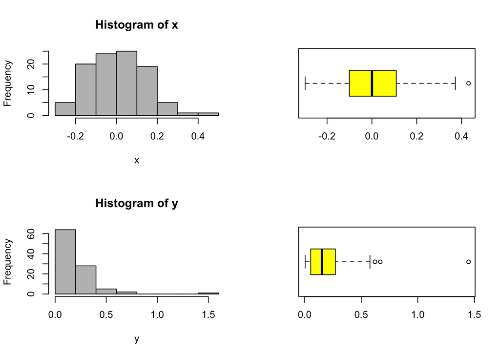

```r
par(mfrow = c(2, 2)) #2 by 2 plot organization
plot1 <- hist(x,col="gray")
plot2 <- boxplot(x,horizontal=TRUE,col="yellow")
plot3 <- hist(y,col="gray")
plot4 <- boxplot(y,horizontal=TRUE,col="yellow")
```

(5)(c) QQ plots are useful for detecting the presence of heavy-tailed distributions. Present side-by-side QQ plots, one for each sample, using *qqnorm()* and *qqline()*. Add color and titles. In base R plots, “cex” can be used to control the size of the plotted data points and text. Lastly, determine if there are any extreme outliers in either sample. Remember: extreme outliers are based on 3.0 x IQR in the box plot. R uses a default value of 1.5 x IQR to define outliers (not extreme) in both boxplot and boxplot stats.

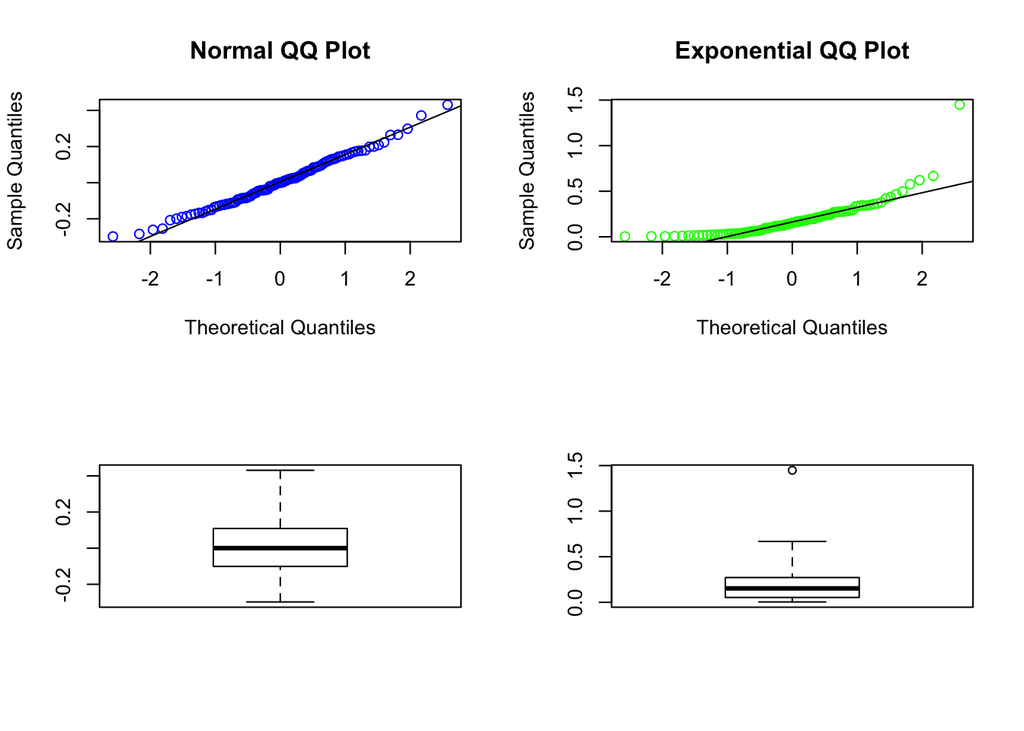

```r
par(mfrow=c(2,2)) #1 row multiple columns setup
qqnorm(x,main="Normal QQ Plot",col="blue")
qqline(x,distribution = qnorm)
qqnorm(y,main="Exponential QQ Plot",col="green")
qqline(y,distribution =qnorm)
boxplot(x, range = 3, do.conf = TRUE, do.out = TRUE)
boxplot(y, range = 3, do.conf = TRUE, do.out = TRUE)
```